# Prediction Assignment

Iain Dalrymple

Tuesday, February 23, 2016

# Introduction

The goal of this data analysis is to predict the manner in which participants in a study did exercise, which is to say how well they did it. The training data set can be downloaded [here](https://d396qusza40orc.cloudfront.net/predmachlearn/pml-training.csv) and the small test set of 20 samples to be evaluated can be downloaded [here](https://d396qusza40orc.cloudfront.net/predmachlearn/pml-testing.csv).

The data for this project comes from this source http://groupware.les.inf.puc-rio.br/har, where further information can be found.

These data are from wearable accelerometers and contain information from these wearable accelerometers under different intensities of exercise.

The modelling will seek to predict the variable “classe” which is a factor with 5 levels. The exercise completed was sets of 10 repetitions of unilateral dumbbell bicep curls.

- Class A was for exercise exactly according to the specification
- Class B was for exercise throwing the elbows to the front
- Class c was for exercise lifting the dumbbell only halfway
- Class D was for exercise lowering the dumbbell only halfway
- Class E was for exercise throwing the hips to the front

## Reproducability

Reproducability has been achieved by setting the seed to 1111 for all code. In order to reproduce the results, this must be maintained in subsequent data interrogations.

# Dataset cleaning and Preparation.

A initial review of the training and testing data sets show that there are 159 columns of data and 19622 rows. There are a significant number of non-numeric data points in the data set, including “NA”, “#DIV/0!” and empty data cells. These have all been converted to NA data.  
Columns with more than 90% of the data as NA have been removed and columns with a near zero variance have been removed by the nearZeroVar() function. Several rows of irrelevant data at the beginning of the data set have been removed also. The resultant final data set has 53 columns and the same number of rows as initially.

The cleaned training data set has been subdivided into a model training set and a model testing set using the createDataPartition() function, with 70% of the data going to the training set grouped by the classe variable. The resultant model training set has 13737 rows of data while the testing set has 5885 rows. This will allow for cross validation and the calculation for out of sample error.

# Model Assesment

Three different modelling methods will be evaluated for this data review. We will compare the efficiency of random forests, naive Bayes and stochastic gradient boosting. Each will be plied using repeated cross validation using K folds with 5 folds and 3 repeats.

From these data, the confusion matrices have been calculated for the training subset and testing subset for each of the models.

### Confusion matrix for Random Forests model training subset

```
## Confusion Matrix and Statistics
##
##           Reference
## Prediction    A    B    C    D    E
##          A 3906    0    0    0    0
##          B    0 2658    0    0    0
##          C    0    0 2396    0    0
##          D    0    0    0 2252    0
##          E    0    0    0    0 2525
##
## Overall Statistics
##
##                Accuracy : 1
##                  95% CI : (0.9997, 1)
##     No Information Rate : 0.2843
##     P-Value [Acc > NIR] : < 2.2e-16
##
##                   Kappa : 1
##  Mcnemar's Test P-Value : NA
##
## Statistics by Class:
##
##                      Class: A Class: B Class: C Class: D Class: E
## Sensitivity            1.0000   1.0000   1.0000   1.0000   1.0000
## Specificity            1.0000   1.0000   1.0000   1.0000   1.0000
## Pos Pred Value         1.0000   1.0000   1.0000   1.0000   1.0000
## Neg Pred Value         1.0000   1.0000   1.0000   1.0000   1.0000
## Prevalence             0.2843   0.1935   0.1744   0.1639   0.1838
## Detection Rate         0.2843   0.1935   0.1744   0.1639   0.1838
## Detection Prevalence   0.2843   0.1935   0.1744   0.1639   0.1838
## Balanced Accuracy      1.0000   1.0000   1.0000   1.0000   1.0000
```

### Confusion matrix for Random Forests model testing subset

```
## Confusion Matrix and Statistics
##
##           Reference
## Prediction    A    B    C    D    E
##          A 1673    1    0    0    0
##          B    4 1131    4    0    0
##          C    0    7 1017    2    0
##          D    0    0   19  945    0
##          E    0    0    1    2 1079
##
## Overall Statistics
##
##                Accuracy : 0.9932
##                  95% CI : (0.9908, 0.9951)
##     No Information Rate : 0.285
##     P-Value [Acc > NIR] : < 2.2e-16
##
##                   Kappa : 0.9914
##  Mcnemar's Test P-Value : NA
##
## Statistics by Class:
##
##                      Class: A Class: B Class: C Class: D Class: E
## Sensitivity            0.9976   0.9930   0.9769   0.9958   1.0000
## Specificity            0.9998   0.9983   0.9981   0.9962   0.9994
## Pos Pred Value         0.9994   0.9930   0.9912   0.9803   0.9972
## Neg Pred Value         0.9991   0.9983   0.9951   0.9992   1.0000
## Prevalence             0.2850   0.1935   0.1769   0.1613   0.1833
## Detection Rate         0.2843   0.1922   0.1728   0.1606   0.1833
## Detection Prevalence   0.2845   0.1935   0.1743   0.1638   0.1839
## Balanced Accuracy      0.9987   0.9956   0.9875   0.9960   0.9997
```

### Confusion matrix for Naive Bayes model training subset

```
## Confusion Matrix and Statistics
##
##           Reference
## Prediction    A    B    C    D    E
##          A 3496   81   93  218   18
##          B  568 1748  181  124   37
##          C  553  154 1606   74    9
##          D  416    5  244 1484  103
##          E  147  223   95   83 1977
##
## Overall Statistics
##
##                Accuracy : 0.7506
##                  95% CI : (0.7433, 0.7578)
##     No Information Rate : 0.3771
##     P-Value [Acc > NIR] : < 2.2e-16
##
##                   Kappa : 0.6807
##  Mcnemar's Test P-Value : < 2.2e-16
##
## Statistics by Class:
##
##                      Class: A Class: B Class: C Class: D Class: E
## Sensitivity            0.6749   0.7906   0.7237   0.7484   0.9221
## Specificity            0.9521   0.9210   0.9314   0.9347   0.9527
## Pos Pred Value         0.8950   0.6576   0.6703   0.6590   0.7830
## Neg Pred Value         0.8287   0.9582   0.9459   0.9566   0.9851
## Prevalence             0.3771   0.1610   0.1615   0.1444   0.1561
## Detection Rate         0.2545   0.1272   0.1169   0.1080   0.1439
## Detection Prevalence   0.2843   0.1935   0.1744   0.1639   0.1838
## Balanced Accuracy      0.8135   0.8558   0.8276   0.8415   0.9374
```

### Confusion matrix for Naive Bayes model testing subset

```
## Confusion Matrix and Statistics
##
##           Reference
## Prediction    A    B    C    D    E
##          A 1492   26   43  100   13
##          B  227  751   95   57    9
##          C  247   69  672   35    3
##          D  186    6  128  596   48
##          E   67   92   39   37  847
##
## Overall Statistics
##
##                Accuracy : 0.7405
##                  95% CI : (0.7291, 0.7517)
##     No Information Rate : 0.3771
##     P-Value [Acc > NIR] : < 2.2e-16
##
##                   Kappa : 0.6678
##  Mcnemar's Test P-Value : < 2.2e-16
##
## Statistics by Class:
##
##                      Class: A Class: B Class: C Class: D Class: E
## Sensitivity            0.6724   0.7956   0.6878   0.7224   0.9207
## Specificity            0.9504   0.9215   0.9279   0.9273   0.9527
## Pos Pred Value         0.8913   0.6594   0.6550   0.6183   0.7828
## Neg Pred Value         0.8274   0.9593   0.9372   0.9535   0.9848
## Prevalence             0.3771   0.1604   0.1660   0.1402   0.1563
## Detection Rate         0.2535   0.1276   0.1142   0.1013   0.1439
## Detection Prevalence   0.2845   0.1935   0.1743   0.1638   0.1839
## Balanced Accuracy      0.8114   0.8585   0.8078   0.8248   0.9367
```

### Confusion matrix for Sochastic Gradient Boosting model training subset

```
## Confusion Matrix and Statistics
##
##           Reference
## Prediction    A    B    C    D    E
##          A 3866   30    6    3    1
##          B   59 2555   40    4    0
##          C    0   46 2324   24    2
##          D    3    4   54 2182    9
##          E    2   17   14   28 2464
##
## Overall Statistics
##
##                Accuracy : 0.9748
##                  95% CI : (0.9721, 0.9774)
##     No Information Rate : 0.2861
##     P-Value [Acc > NIR] : < 2.2e-16
##
##                   Kappa : 0.9681
##  Mcnemar's Test P-Value : 7.852e-10
##
## Statistics by Class:
##
##                      Class: A Class: B Class: C Class: D Class: E
## Sensitivity            0.9837   0.9634   0.9532   0.9737   0.9952
## Specificity            0.9959   0.9907   0.9936   0.9939   0.9946
## Pos Pred Value         0.9898   0.9612   0.9699   0.9689   0.9758
## Neg Pred Value         0.9935   0.9912   0.9899   0.9949   0.9989
## Prevalence             0.2861   0.1931   0.1775   0.1631   0.1802
## Detection Rate         0.2814   0.1860   0.1692   0.1588   0.1794
## Detection Prevalence   0.2843   0.1935   0.1744   0.1639   0.1838
## Balanced Accuracy      0.9898   0.9771   0.9734   0.9838   0.9949
```

### Confusion matrix for Sochastic Gradient Boosting model testing subset

```
## Confusion Matrix and Statistics
##
##           Reference
## Prediction    A    B    C    D    E
##          A 1638   27    4    4    1
##          B   41 1067   31    0    0
##          C    0   36  981    8    1
##          D    0    1   31  928    4
##          E    3    8    6   12 1053
##
## Overall Statistics
##
##                Accuracy : 0.963
##                  95% CI : (0.9578, 0.9676)
##     No Information Rate : 0.2858
##     P-Value [Acc > NIR] : < 2.2e-16
##
##                   Kappa : 0.9531
##  Mcnemar's Test P-Value : 6.388e-06
##
## Statistics by Class:
##
##                      Class: A Class: B Class: C Class: D Class: E
## Sensitivity            0.9738   0.9368   0.9316   0.9748   0.9943
## Specificity            0.9914   0.9848   0.9907   0.9927   0.9940
## Pos Pred Value         0.9785   0.9368   0.9561   0.9627   0.9732
## Neg Pred Value         0.9896   0.9848   0.9852   0.9951   0.9988
## Prevalence             0.2858   0.1935   0.1789   0.1618   0.1799
## Detection Rate         0.2783   0.1813   0.1667   0.1577   0.1789
## Detection Prevalence   0.2845   0.1935   0.1743   0.1638   0.1839
## Balanced Accuracy      0.9826   0.9608   0.9612   0.9837   0.9942
```

```
##                In Sample Error Out of Sample Error
## Random Forests             0.0                 0.7
## Naive Bayes               24.9                25.9
## GBM                        2.5                 3.7
```

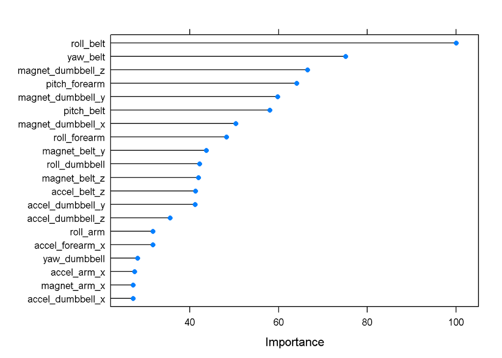

It is clear that there is a clear winner in terms of model prediction accuracy, with Random Forests approach exceeding the other two models in terms of both in sample accuracy and out of sample accuracy.

It is the Random Forests approach that will be used to evaluate the test data set of 20 samples. This is unsurprising as a Random Forest approach is well suited to large data set with numerous inputs with unknown interactions.

# Test Set Predictions

As stated in the introduction, a small test set of 20 samples was also provided to be evaluated by the final Random Forest model. As a check, the predictions were also made from the final Stochastic Gradient Boosting model which was almost as accurate, but not quite. The predictions of both models are shown below. Fortunately, the predictions from both models are identical, giving good confidence in the results.

Predictions from the final Random Forest model

[1] B A B A A E D B A A B C B A E E A B B B Levels: A B C D E

Predictions from the final Stochastic Gradient Boosting model

[1] B A B A A E D B A A B C B A E E A B B B Levels: A B C D E